# 3 Assessing Logistic Regression Models

# 4 Assessing logistic regression models

In linear regression, model assessment often starts with residual sums of squares and $R^2$. Logistic regression uses a different error model, so the assessment tools also change. We still ask the same broad questions:

1. Does adding predictors improve the model?
2. Is the model too simple or unnecessarily complex?
3. Are there unusual observations or structural problems?
4. Are the predicted probabilities useful for the purpose at hand?

This chapter focuses on the first three questions. The next chapter focuses on prediction and classification performance.

## 4.1 Likelihood and deviance

Because logistic regression is fitted by maximum likelihood, model fit is naturally measured through the likelihood. R reports a related quantity called **deviance**.

**Output**

```
         null_deviance     studytime_deviance multivariable_deviance
              500.5040               498.2730               455.1066
```

**Code**

```r
c(
  null_deviance = fit_null$deviance,
  studytime_deviance = fit_study$deviance,
  multivariable_deviance = fit_multi$deviance
)
```

Smaller deviance indicates a better fit to the observed data. The null model has only an intercept, so it represents a baseline model that predicts the same probability for every student.

**Key-point**

Deviance plays a role similar to residual sum of squares in linear regression: it is a lack-of-fit measure, so smaller values indicate better fit. It is likelihood-based rather than squared-error-based.

- Continue

## 4.2 Comparing nested models

Two models are nested when one can be obtained from the other by removing predictors. The study-time model is nested inside the multivariable model because the multivariable model adds `failures` and `absences`.

We can compare nested logistic regression models with a likelihood ratio test:

**Output**

```
Analysis of Deviance Table

Model 1: pass_exam ~ studytime
Model 2: pass_exam ~ studytime + failures + absences
  Resid. Df Resid. Dev Df Deviance  Pr(>Chi)
1       393     498.27
2       391     455.11  2   43.166 4.232e-10 ***
---
Signif. codes:  0 '***' 0.001 '**' 0.01 '*' 0.05 '.' 0.1 ' ' 1
```

**Code**

```r
anova(fit_study, fit_multi, test = "Chisq")
```

The test asks whether the added predictors improve the model enough to justify the extra complexity.

**Note**

Use likelihood ratio tests for nested models. For non-nested models, use information criteria such as AIC or compare prediction performance on a validation set.

## 4.3 AIC and model complexity

The Akaike Information Criterion (AIC) balances model fit and complexity. Lower AIC is preferred among the models being compared.

**Output**

```
          df      AIC
fit_null   1 502.5040
fit_study  2 502.2730
fit_multi  4 463.1066
```

**Code**

```r
AIC(fit_null, fit_study, fit_multi)
```

AIC is useful when comparing several plausible models, but it is not a substitute for subject-matter judgement. A model with a slightly lower AIC but unclear interpretation may not be the best model for communication.

- Continue

## 4.4 Pseudo R-squared

Linear regression’s $R^2$ is based on sums of squares. Logistic regression does not have an exact equivalent. Several **pseudo R-squared** measures exist, but they should be treated as rough summaries rather than as direct analogues.

One common option is McFadden’s pseudo $R^2$:

$$R^2_{\text{McFadden}} = 1 - \frac{\log L_{\text{model}}}{\log L_{\text{null}}}.$$

**Output**

```
[1] 0.09070343
```

**Code**

```r
mcfadden_r2 <- 1 - as.numeric(logLik(fit_multi) / logLik(fit_null))
mcfadden_r2
```

**Key-point**

Do not interpret pseudo $R^2$ as “the percentage of variance explained”. For logistic regression, likelihood-based comparisons and prediction checks are usually more informative.

## 4.5 Residuals and influence

Logistic regression residuals are less visually intuitive than linear regression residuals because the observed outcomes are only 0 or 1. Still, residual and influence diagnostics can help identify observations the model struggles to fit.

**Output**

```
     fitted pearson_residual deviance_residual cooks_distance
1 0.7421124       -1.6963662        -1.6463484   0.0022419032
2 0.7491029       -1.7279171        -1.6629566   0.0023791303
3 0.1297399        2.5899286         2.0210016   0.0435756588
4 0.7632336        0.5569693         0.7351069   0.0004886744
5 0.7491029        0.5787315         0.7601039   0.0002668865
6 0.7277554        0.6116274         0.7972331   0.0003566034
```

**Code**

```r
diagnostics <- data.frame(
  fitted = fitted(fit_multi),
  pearson_residual = residuals(fit_multi, type = "pearson"),
  deviance_residual = residuals(fit_multi, type = "deviance"),
  cooks_distance = cooks.distance(fit_multi)
)
head(diagnostics)
```

**Plot**

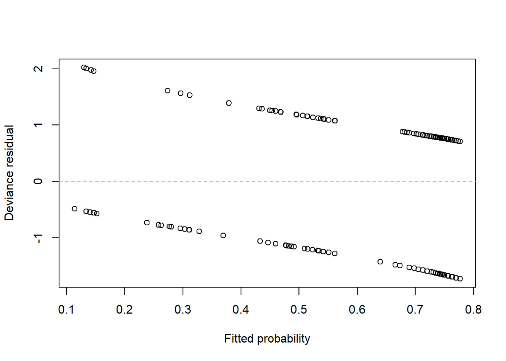

**Code**

```r
plot(diagnostics$fitted, diagnostics$deviance_residual,
     xlab = "Fitted probability",
     ylab = "Deviance residual")
abline(h = 0, col = "grey70", lty = 2)
```

Large residuals mark cases where the observed outcome was surprising under the fitted model. Large Cook’s distances mark cases with unusual influence on the fitted coefficients.

## 4.6 Common problems

**Assumption 3.1:** Independent observations**

The usual logistic regression model assumes observations are independent. If the same person, class, school, or site contributes multiple related observations, the model may need to account for clustering.

**Assumption 3.2:** Linearity on the log-odds scale**

Continuous predictors are assumed to have approximately linear effects on the log-odds. This does not mean a straight line on the probability scale.

Other common problems include:

- **Separation:** a predictor or combination of predictors perfectly separates passes from fails, leading to unstable or very large estimates.
- **Class imbalance:** one outcome class is much more common than the other, so simple accuracy can be misleading.
- **Overfitting:** too many predictors for the amount of data, especially when the event count is small.

## 4.7 Chapter summary

Assessing logistic regression requires likelihood-based thinking. Deviance, likelihood ratio tests, and AIC replace the least-squares tools used in linear regression. Residuals, influence checks, and assumptions still matter, but they must be interpreted through the binary-outcome model.